# predict_cfs_with_CNN

Import the model and make a prediction with real data

```python
%load_ext autoreload
%autoreload 2
```

```python
import re
import os
import sys
import shutil
from shutil import copyfile, copy2
from shutil import move
```

```python
import numpy as np
import pandas as pd
import matplotlib.pyplot as plt
import matplotlib.pylab as pylab
import seaborn as sns
from scipy import stats
# Cause plots to be displayed in the notebook:
%matplotlib inline
```

```python
import subprocess
```

```python
from matplotlib import cm
from latt2D_modules import calc_diffuse, calc_diffuse_cfs3, calc_diffuse_cfs4, calc_diffuse_cfs4_big
from latt2D_modules import get_occ_map, get_2D_occ_map_from_seq,store_occ_map_as_seq
from latt2D_modules import plot_occ_map,read_bin,output_16bit_pgm
import time
```

```python
from tensorflow import keras
from tensorflow.keras import layers
```

[output not shown]

```python
from sklearn.preprocessing import StandardScaler
from sklearn.model_selection import train_test_split
from keras.metrics import MeanSquaredError, MeanAbsoluteError, MeanAbsolutePercentageError, RootMeanSquaredError
from sklearn.metrics import r2_score
from sklearn.metrics import accuracy_score
from sklearn.metrics import mean_squared_error
from sklearn.metrics import mean_absolute_error
import h5py
```

```python
from CFS_CNN_models import reconstruct_small_cfs_model
from CFS_CNN_models import reconstruct_medium_cfs_model
from CFS_CNN_models import reconstruct_large_cfs_model
```

```python
from aux_functions import predict_and_regen_plot
```

```python
import imageio.v2 as imageio
```

```python
from scipy import stats

'''
helper function for univariate stats
'''

def get_univariate_analysis(x):
    # Compute the mean, median, and standard deviation of the sample
    mean = np.mean(x)
    median = np.median(x)
    variance = np.var(x)
    std_dev = np.std(x)

    # Test for normality using the Shapiro-Wilk test
    stat, p_val = stats.shapiro(x)
    if p_val < 0.05:
        normality = "not normally distributed"
    else:
        normality = "normally distributed"

    # Test for skewness using the skewness test
    skewness, p_val = stats.skewtest(x)
    if p_val < 0.05:
        skewness_significance = "significant"
    else:
        skewness_significance = "not significant"

    # Test for kurtosis using the kurtosis test
    kurtosis, p_val = stats.kurtosistest(x)
    if p_val < 0.05:
        kurtosis_significance = "significant"
    else:
        kurtosis_significance = "not significant"

    # Create a pandas dataframe with the computed statistics
    df = pd.DataFrame({'mean': [mean], 'median': [median], 'variance': [variance],
                       'std_dev': [std_dev], 'normality': [normality],
                       'skewness': [skewness], 'skewness_significance': [skewness_significance],
                       'kurtosis': [kurtosis], 'kurtosis_significance': [kurtosis_significance]})
    return df
```

```python
def process_image_and_plot(img,threshold = 1.66, gamma = 20.0, maskoutbragg=False, ut=-2.218, mstd=1.5):

    '''
 stages of image processing
 1. normalized so that mean intensity = 1.0
 2. pixel intensities above a specified threshold are compressed (gamma controls compression curve)
 3. scaling transformation so that log(I) ~ N has a specific u and variance
    default is ut=-2.218, mstd=1.5 where mstd is a multiplier on the std )
    '''


    palette = sns.color_palette("Set2", n_colors=4)

    img=img/np.mean(img.flatten())

    vmax=np.mean(img.flatten())+1.0*np.std(img.flatten())
    fig, axes = plt.subplots(2, 3, figsize=(10,6))
    axes[0,0].imshow(img, cmap='gray',vmax=vmax)
    axes[0,0].set_title('vmax= %.3f [mean(I)+std(I)]'%vmax,size=9)
    axes[0,0].axis('off')
    sns.histplot(ax=axes[0,1], data=img.flatten(), bins=64 , color=palette[0] , kde=True, stat='density',label='norm(I)')
    sns.histplot(ax=axes[0,2], data=np.log(img.flatten()), bins=64 , color=palette[1] , kde=True, stat='density',label='log(I)')
    axes[0,1].set_ylabel('')
    axes[0,2].set_ylabel('')
    axes[0,1].legend()
    axes[0,2].legend()
    axes[0,1].set_title('Original',size=9)
    axes[0,2].set_title('Log(Original)',size=9)
    img_sc=smooth_compress(img, threshold, gamma, maskoutbragg)
    img_fix=transform_log_obs(img_sc.flatten().reshape((64,-1)), ut, mstd)

    vmax=np.max(img_fix.flatten())-2.0*np.std(img_fix.flatten())
    axes[1,0].imshow(img_fix, cmap='gray',vmax=vmax)
    axes[1,0].set_title('vmax= %.3f [max(I)-2.0*std(I)]'%vmax,size=9)
    axes[1,0].axis('off')
    sns.histplot(ax=axes[1,1], data=img_fix.flatten(), bins=64 , color=palette[2] , kde=True, stat='density',label='norm(I)')
    sns.histplot(ax=axes[1,2], data=np.log(img_fix.flatten()), bins=64 , color=palette[3] , kde=True, stat='density',label='log(I)')
    axes[1,1].set_ylabel('')
    axes[1,2].set_ylabel('')
    axes[1,1].legend()
    axes[1,2].legend()
    axes[1,1].set_title('Filtered',size=9)
    axes[1,2].set_title('Log(Filtered)',size=9)

    df_res=get_univariate_analysis(img.flatten())
    df_res=pd.concat([df_res,get_univariate_analysis(np.log(img.flatten()))],axis=0)
    df_res=pd.concat([df_res,get_univariate_analysis(img_fix.flatten())],axis=0)
    df_res=pd.concat([df_res,get_univariate_analysis(np.log(img_fix.flatten()))],axis=0)
    df_res.insert(0, "processed", ["original","log_original","filtered","log_filtered"] )
    df_res.reset_index(drop=True,inplace=True)

    return df_res,img_fix
```

```python
# A compression function

# Define a transformation function that smoothly compresses values above the threshold
def smooth_compress(img, threshold = 50, gamma = 1.0, maskoutbragg=False):
    x=img.flatten()
    y = np.zeros_like(x)
    y[x <= threshold] = x[x <= threshold]
    if maskoutbragg:
        y[x > threshold] = (threshold/gamma) + np.log(1 + (x[x > threshold] - threshold) / threshold)
    else:
        y[x > threshold] = threshold + np.log(1 + (x[x > threshold] - threshold) / (gamma*threshold))

    return y.reshape(img.shape)

# Compress the values using the smooth compression function
# compressed_img = smooth_compress(img)
```

```python
def transform_log_obs(x,ut=-2.218,mstd=1.5):
    '''
    read in x: data that is log normally distributed
            ut: target mean for the
            mstd: multiplier on the desired change in std
    '''

    # define a scaling transform based on the stats from the theoretical data
    log_X=np.log(x)
    mean_log_X=np.mean(log_X)
    var_log_X=np.var(log_X)
    std_log_X=np.std(log_X)

    target_mean= ut # this is the target u for the log(X)
    target_var= (mstd*std_log_X)**2.0  # target std for log(X)

    # normalize the log data
    zn=(log_X-mean_log_X)/var_log_X
    # transform the normed data
    zp= zn*target_var + target_mean
    return np.exp(zp)
```

```python
cfs2_model_sm=reconstruct_small_cfs_model(3,'best_model_5000.h5')
cfs3_model_sm=reconstruct_small_cfs_model(8,'cfs3_best_model_5000.h5')
cfs4_model_sm=reconstruct_small_cfs_model(15,'cfs4_best_model_5000.h5')
cfs4_model_smX13=reconstruct_small_cfs_model(15,'cfs4_sm_X13_incremental.h5')
```

[output not shown]

```python
cfs4_model_mdX13=reconstruct_medium_cfs_model(15,'cfs4_md_X13.h5')
cfs4_model_lgX13=reconstruct_large_cfs_model(15,'cfs4_lg_X13.h5')
```

```python
def get_metrics_compare_predict_with_regen(test_img,corr_in,exp=1):

    corr_in=np.r_[1.0,corr_in]
    corr_out=np.loadtxt('./expfiles_%d/corr.out'%exp)
    imdat_0 = test_img.copy()
    imdat_1 = read_bin('./expfiles_%d/hk0.bin'%exp, npixels=64, offset=1280)

  #  print(corr_in, corr_out.flatten())
  #  print(np.shape(imdat_0))
  #  print(np.shape(imdat_1))
    r2c = r2_score(corr_in.flatten(), corr_out.flatten())
    msec=mean_squared_error(corr_in,corr_out.flatten())
    maec=mean_absolute_error(corr_in,corr_out.flatten())

    r2i=r2_score(imdat_0.flatten(),imdat_1.flatten())
    msei=mean_squared_error(imdat_0.flatten(),imdat_1.flatten())
    maei=mean_absolute_error(imdat_0.flatten(),imdat_1.flatten())
    return [r2c,msec,maec,r2i,msei,maei]
```

```python
# Create a figure and axis for the plot
# Define a function to update the plot
def predict_and_regen_plot_cfs2(test_img):

    iconc=0.50 # spin concentration
    cread=1    # reading correlation function from input file  otherwise it will be generated randomly
    icycles=200  # MC cycles
    ianneal=200  # MC input

    rows,cols =1,4
    fig, axes = plt.subplots(rows, cols, figsize=(10,6))

    axes[0].imshow(test_img.reshape((64,-1)),cmap='gray')
    axes[0].axis("off")

    corrin=cfs2_model.predict(test_img)[0]
    fhout=open('corr.in','w')
    fhout.write("%.6f %.6f\n%.6f %.6f\n"%(1.0,corrin[0],corrin[1],corrin[2]))
    fhout.close()
    calc_diffuse(iconc,1,icycles,ianneal,1) # do the regen on the image

    occ3D=get_occ_map('./expfiles_1/ising2D_occ.txt')
    axes[1].imshow(np.transpose(occ3D[:,:,0]),interpolation='nearest',cmap='gray')
    axes[1].axis("off")
    imdat = read_bin('./expfiles_1/hk0.bin', npixels=64, offset=1280)
    axes[2].imshow(np.flip(imdat,0),cmap='gray')
    axes[2].axis("off")

    corrf2=np.r_[1.0,corrin].reshape((2,-1))
    sns.heatmap(corrf2, ax=axes[3], cmap='bwr', annot=True, square=True, vmin=-1,vmax=1.0, cbar=0) #  cbar_kws={'shrink':0.55})
    axes[3].axis('off')

    my_metrics=get_metrics_compare_predict_with_regen(test_img.reshape((64,-1)),corrin,exp=1)
    fig.suptitle("predicted 01: %.3f 10: %.3f 11: %.3f \n"%(tuple(corrin)) +"metrics(r2, mse, mae)\n corrfunc: %.3f, %.3f, %.3f \n FT_metrics: %.3f, %.3f, %.3f " %(tuple(my_metrics)), fontsize=12,y=0.80)
```

```python
# Create a figure and axis for the plot
# Define a function to update the plot
def predict_and_regen_plot_cfs3(test_img):

    iconc=0.50 # spin concentration
    cread=1    # reading correlation function from input file  otherwise it will be generated randomly
    icycles=200  # MC cycles
    ianneal=200  # MC input

    rows,cols =1,4
    fig, axes = plt.subplots(rows, cols, figsize=(10,6))

    axes[0].imshow(test_img.reshape((64,-1)),cmap='gray')
    axes[0].axis("off")

    corrin=cfs3_model.predict(test_img)[0]
    fhout=open('corr.in','w')
    fhout.write("1.000000 %.6f %.6f\n%.6f %.6f %.6f\n%.6f %.6f %.6f\n"%(tuple(corrin.flatten())))
    fhout.close()
    calc_diffuse_cfs3(iconc,1,icycles,ianneal,1) # do the regen on the image

    corrf3=np.r_[1.0,corrin].reshape((3,-1))
    sns.heatmap(corrf3, ax=axes[3], cmap='bwr', square=True, annot=True, vmin=-1,vmax=1.0, cbar=0)
    axes[3].axis('off')

    occ3D=get_occ_map('./expfiles_1/ising2D_occ.txt')
    axes[1].imshow(np.transpose(occ3D[:,:,0]),interpolation='nearest',cmap='gray')
    axes[1].axis("off")
    imdat = read_bin('./expfiles_1/hk0.bin', npixels=64, offset=1280)
    axes[2].imshow(np.flip(imdat,0),cmap='gray')
    axes[2].axis("off")

    my_metrics=get_metrics_compare_predict_with_regen(test_img.reshape((64,-1)),corrin,exp=1)
    fig.suptitle("metrics(r2, mse, mae)\n corrfunc: %.3f, %.3f, %.3f \n FT_metrics: %.3f, %.3f, %.3f " %(tuple(my_metrics)), fontsize=12,y=0.80)
```

```python
# Create a figure and axis for the plot
# Define a function to update the plot
def predict_and_regen_plot_cfs4(test_img):

    iconc=0.50 # spin concentration
    cread=1    # reading correlation function from input file  otherwise it will be generated randomly
    icycles=300  # MC cycles
    ianneal=300  # MC input

    rows,cols =1,4
    fig, axes = plt.subplots(rows, cols, figsize=(14,6))

    axes[0].imshow(test_img.reshape((64,-1)),cmap='gray')
    axes[0].axis("off")

    corrin=cfs4_model.predict(test_img)[0]
    fhout=open('corr.in','w')
    fhout.write("1.000000 %.6f %.6f %.6f\n%.6f %.6f %.6f %.6f\n%.6f %.6f %.6f %.6f\n%.6f %.6f %.6f %.6f\n"%(tuple(corrin.flatten())))
    fhout.close()
    calc_diffuse_cfs4(iconc,1,icycles,ianneal,1) # do the regen on the image

    corrf4=np.r_[1.0,corrin].reshape((4,-1))
    sns.heatmap(corrf4, ax=axes[3], cmap='bwr', annot=True, square=True, vmin=-1,vmax=1.0,fmt=".3f" ,cbar=0 )
    axes[3].axis('off')

    occ3D=get_occ_map('./expfiles_1/ising2D_occ.txt')
    axes[1].imshow(np.transpose(occ3D[:,:,0]),interpolation='nearest',cmap='gray')
    axes[1].axis("off")
    imdat = read_bin('./expfiles_1/hk0.bin', npixels=64, offset=1280)
    axes[2].imshow(np.flip(imdat,0),cmap='gray')
    axes[2].axis("off")

    my_metrics=get_metrics_compare_predict_with_regen(test_img.reshape((64,-1)),corrin,exp=1)
    fig.suptitle("metrics(r2, mse, mae)\n corrfunc: %.3f, %.3f, %.3f \n FT_metrics: %.3f, %.3f, %.3f " %(tuple(my_metrics)), fontsize=14,y=0.88)
```

```python
obs_path='./obs_data_prep_for_testing/'
```

```python
# grabbing the raw image
img_dcdnb_hk0_box1 = imageio.imread(obs_path+'dcdnb_hk0_box1_64x64.tif').astype(float)
```

|  | processed | mean | median | variance | std_dev | normality | skewness | skewness_significance | kurtosis | kurtosis_significance |
| --- | --- | --- | --- | --- | --- | --- | --- | --- | --- | --- |
| 0 | original | 1.000000 | 0.864191 | 0.911648 | 0.954803 | not normally distributed | 76.083846 | significant | 43.661071 | significant |
| 1 | log_original | -0.080273 | -0.145962 | 0.081160 | 0.284887 | not normally distributed | 55.175337 | significant | 36.095530 | significant |
| 2 | filtered | 0.121149 | 0.097498 | 0.005552 | 0.074514 | not normally distributed | 45.824290 | significant | 29.804490 | significant |
| 3 | log_filtered | -2.218000 | -2.327925 | 0.170234 | 0.412594 | not normally distributed | 30.433480 | significant | 16.780362 | significant |

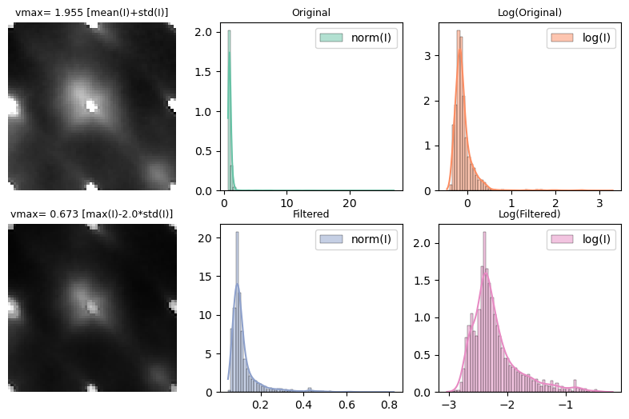

```python
df_res,img_fix=process_image_and_plot(img_dcdnb_hk0_box1,threshold = 1.66, gamma = 20.0, maskoutbragg=False, ut=-2.218, mstd=1.5)
df_res
```

```python
# shape image for prediction
test_img=np.expand_dims(img_fix, axis=(0,-1))
np.shape(test_img)
```

```
(1, 64, 64, 1)
```

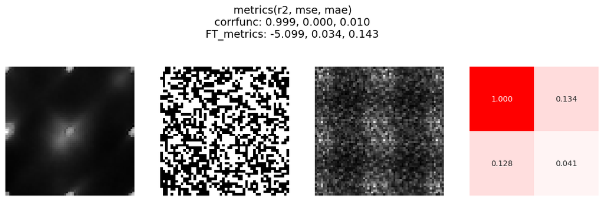

```python
# myimg=test_img.reshape((64,-1))
# plt.imshow(myimg,cmap='gray')
corrin=cfs2_model_sm.predict(test_img)[0]
predict_and_regen_plot(calc_diffuse,test_img,corrin,cfs=2,iconc=0.5,icycles=200,ianneal=200)
```

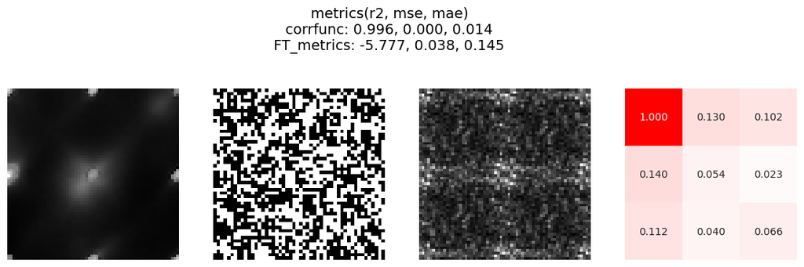

```python
corrin=cfs3_model_sm.predict(test_img)[0]
predict_and_regen_plot(calc_diffuse_cfs3,test_img,corrin,cfs=3,iconc=0.5,icycles=200,ianneal=200)
```

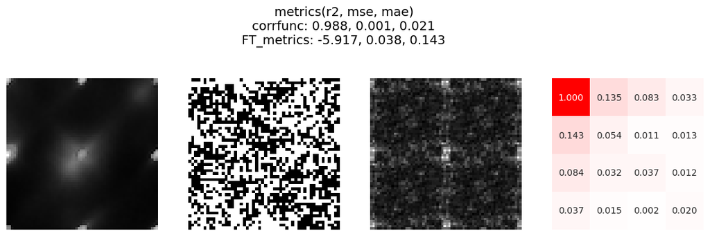

```python
corrin=cfs4_model_sm.predict(test_img)[0]
predict_and_regen_plot(calc_diffuse_cfs4,test_img,corrin,cfs=4,iconc=0.5,icycles=300,ianneal=300)
```

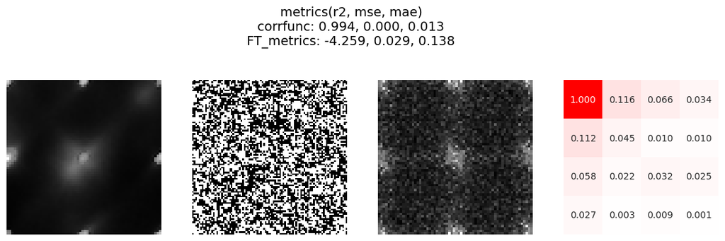

```python
corrin=cfs4_model_smX13.predict(test_img)[0]
predict_and_regen_plot(calc_diffuse_cfs4_big,test_img,corrin,cfs=4,iconc=0.5,icycles=500,ianneal=500)
```

[figure not shown]

```python
corrin=cfs4_model_mdX13.predict(test_img)[0]
predict_and_regen_plot(calc_diffuse_cfs4_big,test_img,corrin,cfs=4,iconc=0.5,icycles=500,ianneal=500)
```

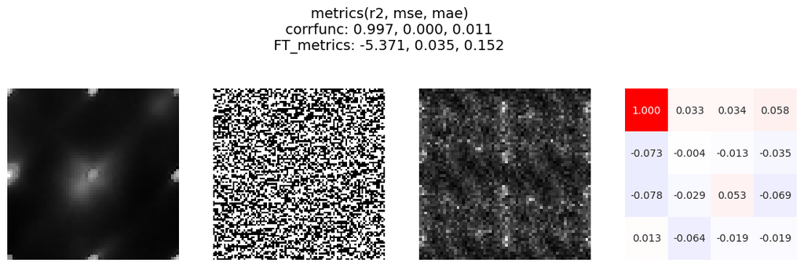

```python
corrin=cfs4_model_lgX13.predict(test_img)[0]
predict_and_regen_plot(calc_diffuse_cfs4_big,test_img,corrin,cfs=4,iconc=0.5,icycles=500,ianneal=500)
```

```python
# grabbing the raw image
img_hk0_box2 = imageio.imread(obs_path+'hk0_box2_64x64.tif').astype(float)
```

|  | processed | mean | median | variance | std_dev | normality | skewness | skewness_significance | kurtosis | kurtosis_significance |
| --- | --- | --- | --- | --- | --- | --- | --- | --- | --- | --- |
| 0 | original | 1.000000 | 0.801308 | 2.605537 | 1.614168 | not normally distributed | 74.716006 | significant | 43.213754 | significant |
| 1 | log_original | -0.171920 | -0.221510 | 0.154921 | 0.393600 | not normally distributed | 51.508209 | significant | 33.916966 | significant |
| 2 | filtered | 0.824363 | 0.812881 | 0.037180 | 0.192822 | not normally distributed | 29.201890 | significant | 24.131795 | significant |
| 3 | log_filtered | -0.218000 | -0.207170 | 0.048290 | 0.219750 | not normally distributed | 9.524045 | significant | 3.488362 | significant |

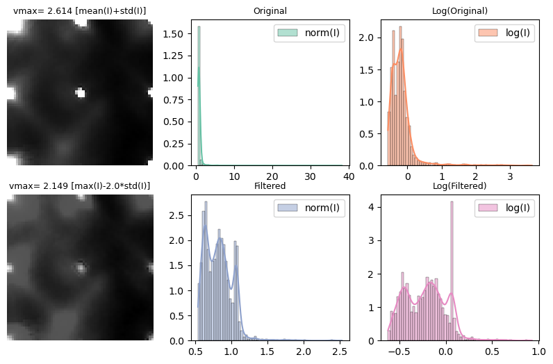

```python
df_res,img_fix=process_image_and_plot(img_hk0_box2,threshold = 1.0, gamma = 20.0, maskoutbragg=False, ut=-0.218, mstd=1.1)
df_res
```

```python
# shape image for prediction
test_img=np.expand_dims(img_fix, axis=(0,-1))
np.shape(test_img)
```

```
(1, 64, 64, 1)
```

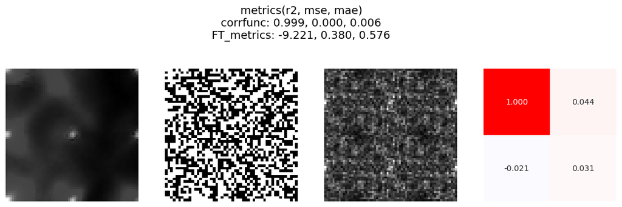

```python
# myimg=test_img.reshape((64,-1))
# plt.imshow(myimg,cmap='gray')
corrin=cfs2_model_sm.predict(test_img)[0]
predict_and_regen_plot(calc_diffuse,test_img,corrin,cfs=2,iconc=0.5,icycles=200,ianneal=200)
```

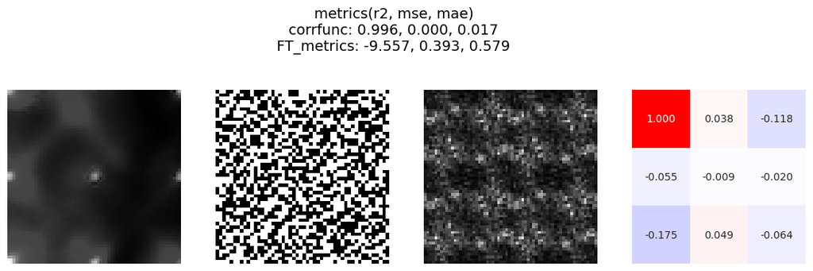

```python
# myimg=test_img.reshape((64,-1))
# plt.imshow(myimg,cmap='gray')
corrin=cfs3_model_sm.predict(test_img)[0]
predict_and_regen_plot(calc_diffuse_cfs3,test_img,corrin,cfs=3,iconc=0.5,icycles=200,ianneal=200)
```

[figure not shown]

```python
# myimg=test_img.reshape((64,-1))
# plt.imshow(myimg,cmap='gray')
corrin=cfs4_model_sm.predict(test_img)[0]
predict_and_regen_plot(calc_diffuse_cfs4,test_img,corrin,cfs=4,iconc=0.5,icycles=300,ianneal=300)
```

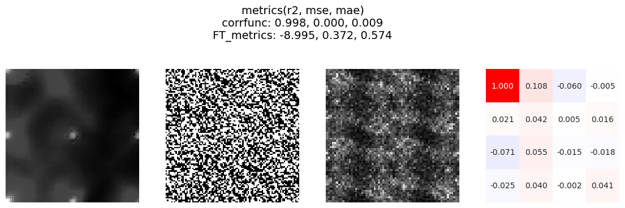

```python
# myimg=test_img.reshape((64,-1))
# plt.imshow(myimg,cmap='gray')
corrin=cfs4_model_smX13.predict(test_img)[0]
predict_and_regen_plot(calc_diffuse_cfs4_big,test_img,corrin,cfs=4,iconc=0.5,icycles=300,ianneal=300)
```

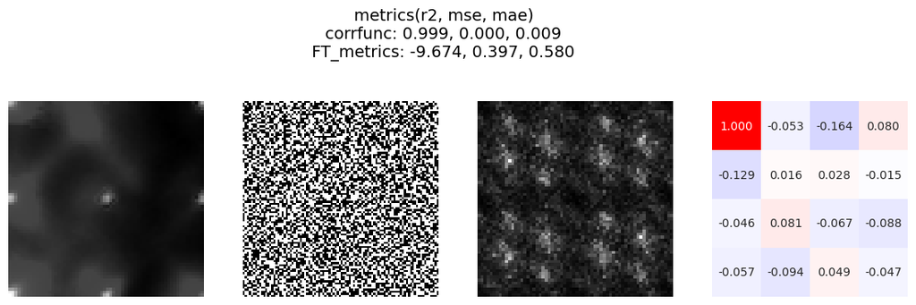

```python
# myimg=test_img.reshape((64,-1))
# plt.imshow(myimg,cmap='gray')
corrin=cfs4_model_mdX13.predict(test_img)[0]
predict_and_regen_plot(calc_diffuse_cfs4_big,test_img,corrin,cfs=4,iconc=0.5,icycles=300,ianneal=300)
```

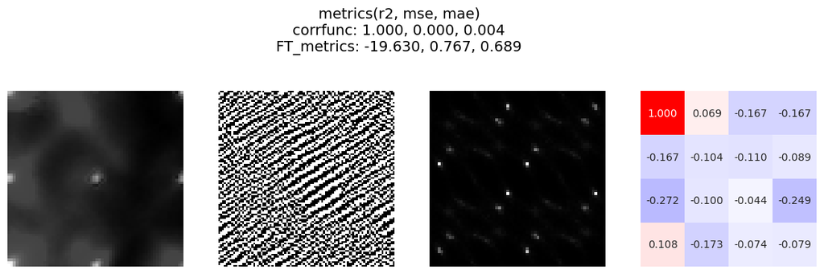

```python
# myimg=test_img.reshape((64,-1))
# plt.imshow(myimg,cmap='gray')
corrin=cfs4_model_lgX13.predict(test_img)[0]
predict_and_regen_plot(calc_diffuse_cfs4_big,test_img,corrin,cfs=4,iconc=0.5,icycles=300,ianneal=300)
```

# cross prediction from theoretical data.

```python
# read in  correlation datum  for CFS2 griding
df_cfs2=pd.read_csv('output_correlations_1000.csv')
df_cfs2=df_cfs2.drop('Unnamed: 0',axis=1)
df_cfs2.reset_index(inplace=True,drop=True)
xvar=np.random.randint(0,len(df_cfs2),1)[0]
bin_dir='image_inputs_bin'
test_img = read_bin('%s/hk0_%s.bin'%(bin_dir,str(xvar).zfill(6)), npixels=64, offset=1280)
print(df_cfs2.iloc[xvar])
```

```
00    0.999836
01   -0.440164
10   -0.243364
11   -0.308964
Name: 32, dtype: float64
```

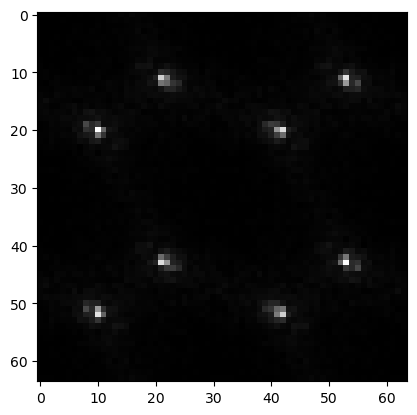

```python
plt.imshow(np.flip(test_img,0),cmap='gray')
```

```python
test_img=np.expand_dims(test_img, axis=(0,-1))
np.shape(test_img)
```

```
(1, 64, 64, 1)
```

#### just realized i needed to transpose the correlation matrix so that it makes sense with the input image

#### and the output microstructure which should have in real space the a-axis as horizontal etc.

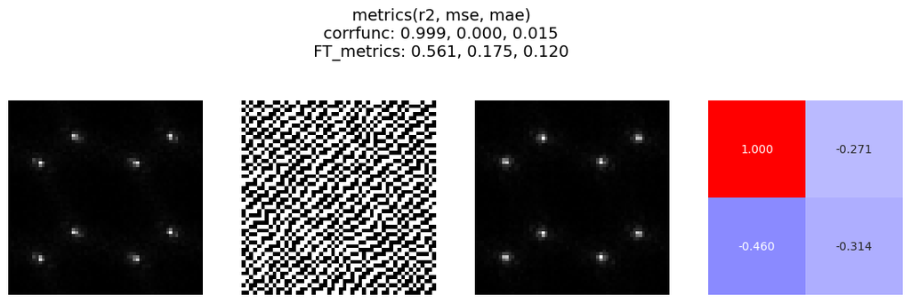

```python
corrin=cfs2_model_sm.predict(test_img)[0]
predict_and_regen_plot(calc_diffuse,test_img,corrin,cfs=2,iconc=0.5,icycles=200,ianneal=200)
```

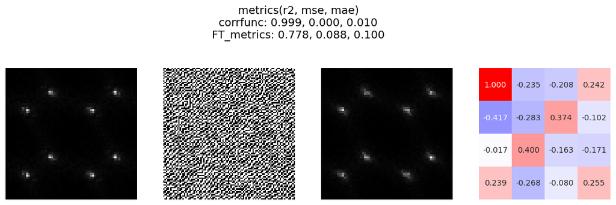

```python
corrin=cfs4_model_smX13.predict(test_img)[0]
predict_and_regen_plot(calc_diffuse_cfs4_big,test_img,corrin,cfs=4,iconc=0.5,icycles=300,ianneal=300)
```

```python
# read in  correlation datum  for CFS4 griding
df_cfs4=pd.read_csv('cfs4_big_corr_out_1.csv')
df_cfs4=df_cfs4.drop('Unnamed: 0',axis=1)
df_cfs4.reset_index(inplace=True,drop=True)
xvar=np.random.randint(0,len(df_cfs4),1)[0]
bin_dir='cfs4_big_bin_1/'
test_img = read_bin('%s/hk0_%s.bin'%(bin_dir,str(xvar).zfill(6)), npixels=64, offset=1280)
print(df_cfs4.iloc[xvar])
```

```
00    0.999763
01    0.409051
02    0.043165
03    0.010613
10   -0.146939
11   -0.153883
12    0.015822
13   -0.197720
20   -0.472026
21   -0.340949
22   -0.081835
23   -0.268901
30    0.411655
31    0.292297
32    0.097853
33    0.300544
Name: 712, dtype: float64
```

```python
test_img=np.expand_dims(test_img, axis=(0,-1))
np.shape(test_img)
```

```
(1, 64, 64, 1)
```

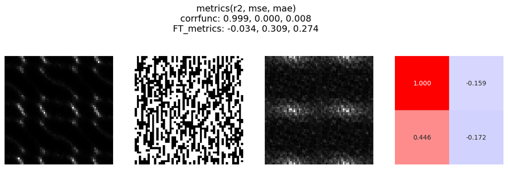

```python
corrin=cfs2_model_sm.predict(test_img)[0]
predict_and_regen_plot(calc_diffuse,test_img,corrin,cfs=2,iconc=0.5,icycles=200,ianneal=200)
```

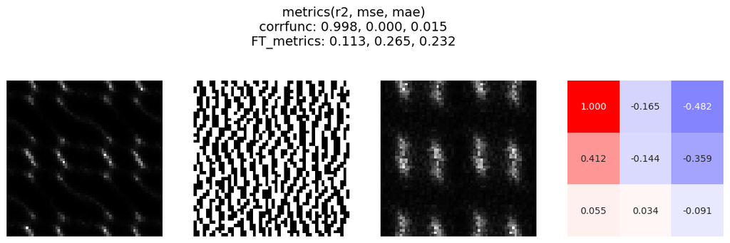

```python
corrin=cfs3_model_sm.predict(test_img)[0]
predict_and_regen_plot(calc_diffuse_cfs3,test_img,corrin,cfs=3,iconc=0.5,icycles=200,ianneal=200)
```

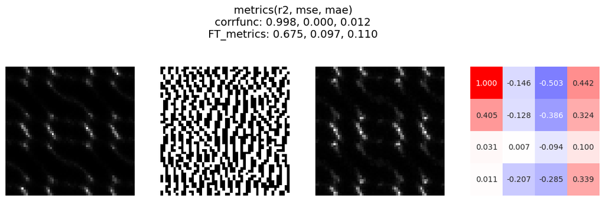

```python
corrin=cfs4_model_sm.predict(test_img)[0]
predict_and_regen_plot(calc_diffuse_cfs4,test_img,corrin,cfs=4,iconc=0.5,icycles=200,ianneal=200)
```

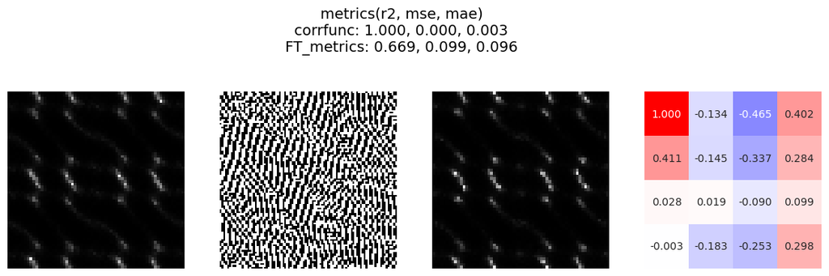

```python
corrin=cfs4_model_smX13.predict(test_img)[0]
predict_and_regen_plot(calc_diffuse_cfs4_big,test_img,corrin,cfs=4,iconc=0.5,icycles=300,ianneal=300)
```

# early cleaning up the observed data and running tests